# Week 4: Activity 1

Calum Smith

2026-02-02

# Introduction

This report presents an initial descriptive analysis to assess whether the dataset supports a clear and defensible narrative relevant to the client’s stated objective. The emphasis at this stage is on establishing a transparent evidential basis for subsequent analysis, rather than pursuing complex modelling. Specifically, the report aims to (i) characterise the sample, (ii) assess baseline comparability between groups on observed covariates, and (iii) identify issues that may affect interpretability, including limitations in measurement or coverage.

# Client Brief

The client has requested an assessment of whether the dataset contains a pattern that is relevant to decision-making, sufficiently consistent to justify communication to a broad audience, and not readily explained by straightforward artefacts (for example, changes in who is included, missingness, or definitional changes). The required output is an evidence-led summary with an explicit claim, supporting evidence, limitations with impact, and a concrete recommendation for next steps.

# Data Description

The dataset contains 238 customers split into two groups: Control (n=120) and Treatment (n=118). For each customer, the dataset includes customer age, customer type, average order value in GBP, number of orders placed in the past 90 days, number of website sessions in the last 30 days prior to the extract date, whether the customer is eligible for a discount under the intervention rules, area-level affluence score associated with the customer’s location and whether the customer made at least one purchase in the 30 days after the intervention/extract reference point. The operational meaning of the outcome is assumed to be consistent across records but should be verified against the source system definition.

# Baseline summary of data characteristics

# Claim

# Data and approach (plain language)

The analysis is descriptive. We do not fit outcome models or claim causal effects. We use the baseline summary table to characterise the sample and check for obvious differences in group composition, then use two simple visuals: (i) a plot of the customer type across the groups; and (ii) a plot of Average Order Value (£) distributions by group as an example check to illustrate the skewness of the data.

**Table 1. Characteristics by Group (Data Version: original )**

| **Variable** | **N** | **Overall** N = 238 | **Control** N = 120 | **Treatment** N = 118 | **SMD**<sup>1</sup> |
| --- | --- | --- | --- | --- | --- |
| Customer Age, Mean (SD) | 238 | 44 (12) | 45 (12) | 43 (13) | 0.127 |
| Avg Order Value (£), Mean (SD) | 238 | 46 (23) | 46 (24) | 46 (22) | 0.008 |
| Orders Last (90 Days), n (%) | 238 |  |  |  | 0.127 |
| 0 |  | 19 (8.0%) | 11 (9.2%) | 8 (6.8%) |  |
| 1 |  | 54 (23%) | 25 (21%) | 29 (25%) |  |
| 2 |  | 54 (23%) | 27 (23%) | 27 (23%) |  |
| 3 |  | 50 (21%) | 22 (18%) | 28 (24%) |  |
| 4 |  | 35 (15%) | 20 (17%) | 15 (13%) |  |
| 5 |  | 15 (6.3%) | 7 (5.8%) | 8 (6.8%) |  |
| 6 |  | 4 (1.7%) | 2 (1.7%) | 2 (1.7%) |  |
| 7 |  | 5 (2.1%) | 4 (3.3%) | 1 (0.8%) |  |
| 8 |  | 2 (0.8%) | 2 (1.7%) | 0 (0%) |  |
| Web Sessions Last 30d, Mean (SD) | 238 | 7.4 (3.1) | 7.4 (3.1) | 7.3 (3.2) | 0.017 |
| Area Affluence Score, Mean (SD) | 238 | 29 (11) | 29 (10) | 30 (12) | -0.073 |
| Customer Type, n (%) | 238 |  |  |  | 0.152 |
| Existing |  | 148 (62%) | 79 (66%) | 69 (58%) |  |
| New |  | 90 (38%) | 41 (34%) | 49 (42%) |  |
| Discount Eligible, n (%) | 238 | 58 (24%) | 31 (26%) | 27 (23%) | 0.069 |
| Made Purchase 30d, n (%) | 238 | 74 (31%) | 35 (29%) | 39 (33%) | 0.084 |

<sup>1</sup> Standardized Mean Difference

# Evidence

## Baseline summary table & Interpretation

The baseline summary table reports key covariates by group. For this expert version we include standardised mean differences (SMDs) to quantify baseline imbalance.

# Visualisation 1 & Interpretation

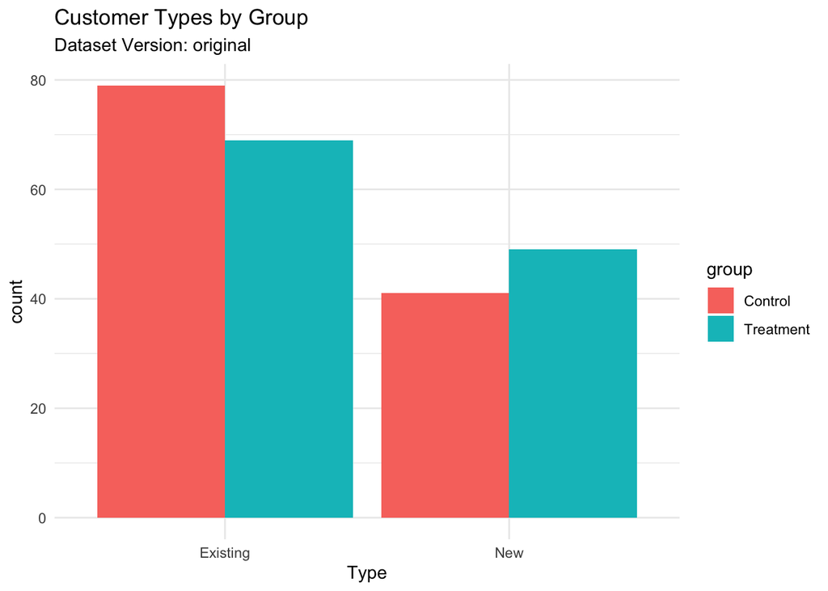

Visualisation 1: Count of Existing and New customers per group.

**Interpretation**: Both groups exhibit similar counts of both Existing and New customers.

# Visualisation 2 & Interpretation

Visualisation 2 compares the Average Order Value (£) distributions by group.

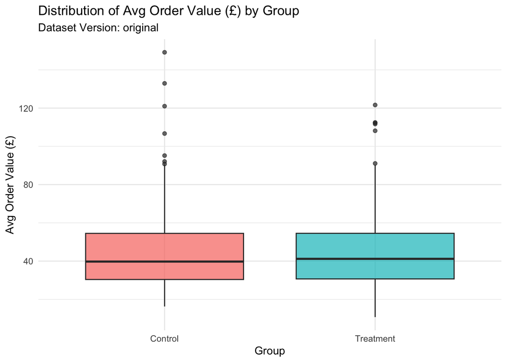

Visualisation 2: Average Order Value (£) by Group.

**Interpretation**: Average Order Value (£) distributions significantly overlap across the groups however, both contain outliers indicating the data for each group is right-skewed.

# Uncertainty & Limitations

- Influence of Outliers: The AOV distribution is right-skewed with significant outliers. These extreme values can disproportionately pull the mean, potentially masking the typical customer behavior represented by the median.
- Ambiguity in Assignment Rules: The specific logic used to assign customers to “Treatment” or “Control” groups is currently undocumented; if this allocation was based on any non-random criteria, the observed differences in outcomes may be driven by selection bias rather than the intervention itself.

# Recommendation & Next Steps

Sensitivity analysis on outliers to ensure the findings are robust and not driven by the top 1% of spenders. If definitions are stable, proceed to an adjusted analysis aligned to the client decision context before communicating a public-facing narrative.